# CA on the ‘Mortality’ dataset

Denaldo Lapi, Samy Chouti, Franscesco Aristei

27 March 2022

```r
# delete R objects left in memory
rm(list = ls())
```

```r
# install needed packages
#install.packages(c("FactoMineR", "factoextra", "gplots", "corrplot"))
```

```r
# load libraries
library(FactoMineR) # for CA
```

```r
library(factoextra) # for ggplot visualizations
```

## Exploratory data analysis

```r
# load the data
data("mortality")
```

```r
# inspect the dataset
head(mortality) # first rows
```

|  | 15-24 (79) | 25-34 (79) | 35-44 (79) | 45-54 (79) | 55-64 (79) | 65-74 (79) | 75-84 (79) | 85-94 (79) | 95 and more (79) | 15-24 (06) | 25-34 (06) | 35-44 (06) | 45-54 (06) | 55-64 (06) | 65-74 (06) | 75-84 (06) | 85-94 (06) | 95 and more (06) |
| --- | --- | --- | --- | --- | --- | --- | --- | --- | --- | --- | --- | --- | --- | --- | --- | --- | --- | --- |
| Accidental poisoning | 82 | 72 | 54 | 64 | 43 | 74 | 73 | 40 | 1 | 54 | 109 | 141 | 135 | 89 | 97 | 196 | 159 | 27 |
| Addiction to prescription medication | 7 | 4 | 2 | 6 | 6 | 2 | 6 | 0 | 0 | 18 | 77 | 72 | 15 | 4 | 2 | 1 | 0 | 0 |
| Alcohol abuse and alcohol-related psychosis | 15 | 135 | 360 | 862 | 757 | 806 | 391 | 43 | 2 | 14 | 79 | 403 | 977 | 786 | 397 | 245 | 52 | 3 |
| Asthma | 17 | 28 | 29 | 102 | 167 | 397 | 556 | 184 | 15 | 12 | 11 | 30 | 81 | 99 | 138 | 290 | 280 | 52 |
| Blood and hematopoietic disorders | 30 | 38 | 47 | 110 | 192 | 482 | 838 | 417 | 23 | 20 | 22 | 43 | 94 | 159 | 259 | 642 | 670 | 213 |
| Cerebrovascular disease | 92 | 269 | 551 | 1924 | 3597 | 13683 | 28719 | 16169 | 1153 | 35 | 75 | 311 | 902 | 1575 | 3719 | 12172 | 11385 | 2464 |

Let’s see a brief summary of the main statistics of the dataset:

```r
summary(mortality)
```

```
   15-24 (79)        25-34 (79)       35-44 (79)        45-54 (79)       55-64 (79)       65-74 (79)        75-84 (79)
 Min.   :   0.00   Min.   :   2.0   Min.   :   2.00   Min.   :   0.0   Min.   :   0.0   Min.   :    0.0   Min.   :    0.0
 1st Qu.:   8.00   1st Qu.:  17.0   1st Qu.:  31.25   1st Qu.:  65.0   1st Qu.: 104.5   1st Qu.:  263.2   1st Qu.:  362.2
 Median :  17.00   Median :  38.0   Median :  86.50   Median : 270.0   Median : 463.5   Median : 1085.5   Median : 1112.0
 Mean   : 144.18   Mean   : 153.7   Mean   : 226.69   Mean   : 611.1   Mean   : 879.2   Mean   : 2000.8   Mean   : 2864.3
 3rd Qu.:  66.75   3rd Qu.: 130.2   3rd Qu.: 293.25   3rd Qu.: 822.2   3rd Qu.:1085.0   3rd Qu.: 2208.8   3rd Qu.: 3050.0
 Max.   :3439.00   Max.   :1666.0   Max.   :1308.00   Max.   :3751.0   Max.   :5462.0   Max.   :14882.0   Max.   :28719.0
   85-94 (79)      95 and more (79)   15-24 (06)       25-34 (06)        35-44 (06)        45-54 (06)        55-64 (06)
 Min.   :    0.0   Min.   :   0.0   Min.   :   0.0   Min.   :   0.00   Min.   :   0.00   Min.   :   1.00   Min.   :   0.00
 1st Qu.:  125.2   1st Qu.:   3.0   1st Qu.:   3.0   1st Qu.:   9.25   1st Qu.:  31.25   1st Qu.:  83.25   1st Qu.:  95.25
 Median :  403.5   Median :  19.5   Median :   9.5   Median :  30.00   Median :  77.50   Median : 245.50   Median : 458.00
 Mean   : 1529.0   Mean   : 138.9   Mean   :  56.1   Mean   :  83.65   Mean   : 197.23   Mean   : 506.52   Mean   : 814.42
 3rd Qu.: 1221.8   3rd Qu.:  76.5   3rd Qu.:  38.0   3rd Qu.:  76.50   3rd Qu.: 269.75   3rd Qu.: 602.75   3rd Qu.:1215.00
 Max.   :16169.0   Max.   :1716.0   Max.   :1214.0   Max.   :1141.00   Max.   :1972.00   Max.   :4059.00   Max.   :7285.00
   65-74 (06)       75-84 (06)        85-94 (06)      95 and more (06)
 Min.   :   0.0   Min.   :    0.0   Min.   :    0.0   Min.   :   0.0
 1st Qu.: 127.5   1st Qu.:  270.5   1st Qu.:  178.8   1st Qu.:  17.0
 Median : 774.5   Median : 1159.5   Median :  754.0   Median :  94.5
 Mean   :1240.0   Mean   : 2576.0   Mean   : 2206.1   Mean   : 560.6
 3rd Qu.:1718.0   3rd Qu.: 3101.5   3rd Qu.: 2452.8   3rd Qu.: 522.0
 Max.   :8026.0   Max.   :13739.0   Max.   :17627.0   Max.   :5738.0
```

The “mortality” dataset is a data frame with 62 rows (the different causes of death) and 18 columns. Each column corresponds to an age interval (15-24, 25-34, 35-44, 45-54, 55-64, 65-74, 75-84, 85-94, 95 and more) in a year. The first 9 columns correspond to data in 1979 and the 9 last columns to data in 2006. In each cell, the count of deaths for a cause of death in an age interval (in a year) is given.

The first 9 cols correspond to data in 1979 and the 9 last columns correspond to data in 2006.

## CA on the first 8 columns

```r
res.ca <- CA(mortality[, 1:8], graph = FALSE) # don't show CA graph
```

Due to the high number of row points , the CA graph (factor map) is obviously very difficult to interpret because of many overlappings, that’s why we’ll try to visualize the result of the CA in a smarter way. At first, let’s see a summary of the performed CA to obtain some first insights:

```r
summary(res.ca)
```

```
Call:
CA(X = mortality[, 1:8], graph = FALSE)

The chi square of independence between the two variables is equal to 239664 (p-value =  0 ).

Eigenvalues
                       Dim.1   Dim.2   Dim.3   Dim.4   Dim.5   Dim.6   Dim.7
Variance               0.287   0.132   0.024   0.012   0.002   0.001   0.000
% of var.             62.507  28.808   5.301   2.712   0.491   0.144   0.036
Cumulative % of var.  62.507  91.316  96.616  99.328  99.820  99.964 100.000

Rows (the 10 first)
                                                                               Iner*1000    Dim.1    ctr   cos2    Dim.2    ctr   cos2
Accidental poisoning                                                         |     2.496 |  1.523  0.777  0.894 |  0.492  0.176  0.093
Addiction to prescription medication                                         |     0.218 |  1.743  0.067  0.881 |  0.411  0.008  0.049
Alcohol abuse and alcohol-related psychosis                                  |     7.607 |  0.629  0.891  0.337 | -0.759  2.814  0.490
Asthma                                                                       |     0.086 | -0.016  0.000  0.008 | -0.093  0.019  0.286
Blood and hematopoietic disorders                                            |     0.078 | -0.087  0.011  0.404 |  0.083  0.022  0.370
Cerebrovascular disease                                                      |    18.028 | -0.322  4.501  0.717 |  0.193  3.504  0.257
Chronic liver disease                                                        |    30.820 |  0.467  2.314  0.216 | -0.842 16.369  0.703
Complications in pregnancy and childbirth                                    |     3.732 |  3.533  0.758  0.584 |  1.718  0.389  0.138
Congenital defects of the circulatory system                                 |     2.120 |  1.937  0.686  0.930 |  0.494  0.097  0.060
Congenital defects of the nervous system                                     |     0.806 |  2.354  0.226  0.805 |  0.938  0.078  0.128
                                                                                Dim.3    ctr   cos2
Accidental poisoning                                                         |  0.088  0.031  0.003 |
Addiction to prescription medication                                         | -0.145  0.005  0.006 |
Alcohol abuse and alcohol-related psychosis                                  |  0.418  4.625  0.148 |
Asthma                                                                       | -0.115  0.154  0.434 |
Blood and hematopoietic disorders                                            | -0.031  0.016  0.050 |
Cerebrovascular disease                                                      | -0.027  0.379  0.005 |
Chronic liver disease                                                        |  0.249  7.771  0.061 |
Complications in pregnancy and childbirth                                    |  0.600  0.258  0.017 |
Congenital defects of the circulatory system                                 |  0.017  0.001  0.000 |
Congenital defects of the nervous system                                     | -0.266  0.034  0.010 |

Columns
                                                                               Iner*1000     Dim.1     ctr    cos2     Dim.2     ctr
15-24 (79)                                                                   |   155.931 |   2.661  42.264   0.779 |   1.288  21.482
25-34 (79)                                                                   |    72.157 |   1.803  20.694   0.824 |   0.556   4.264
35-44 (79)                                                                   |    33.528 |   1.029   9.938   0.852 |  -0.148   0.449
45-54 (79)                                                                   |    46.031 |   0.518   6.784   0.424 |  -0.546  16.357
55-64 (79)                                                                   |    34.209 |   0.240   2.095   0.176 |  -0.509  20.460
65-74 (79)                                                                   |    17.954 |  -0.033   0.091   0.015 |  -0.229   9.463
75-84 (79)                                                                   |    32.141 |  -0.259   7.964   0.712 |   0.131   4.426
85-94 (79)                                                                   |    67.739 |  -0.401  10.168   0.431 |   0.410  23.099
                                                                                cos2     Dim.3     ctr    cos2
15-24 (79)                                                                     0.182 |  -0.461  14.928   0.023 |
25-34 (79)                                                                     0.078 |   0.279   5.840   0.020 |
35-44 (79)                                                                     0.018 |   0.335  12.387   0.090 |
45-54 (79)                                                                     0.471 |   0.216  13.889   0.074 |
55-64 (79)                                                                     0.792 |   0.020   0.167   0.001 |
65-74 (79)                                                                     0.698 |  -0.139  18.762   0.255 |
75-84 (79)                                                                     0.182 |  -0.074   7.641   0.058 |
85-94 (79)                                                                     0.452 |   0.188  26.387   0.095 |
```

```r
# obtained  CA object
res.ca
```

```
**Results of the Correspondence Analysis (CA)**
The row variable has  62  categories; the column variable has 8 categories
The chi square of independence between the two variables is equal to 239664 (p-value =  0 ).
*The results are available in the following objects:

   name              description
1  "$eig"            "eigenvalues"
2  "$col"            "results for the columns"
3  "$col$coord"      "coord. for the columns"
4  "$col$cos2"       "cos2 for the columns"
5  "$col$contrib"    "contributions of the columns"
6  "$row"            "results for the rows"
7  "$row$coord"      "coord. for the rows"
8  "$row$cos2"       "cos2 for the rows"
9  "$row$contrib"    "contributions of the rows"
10 "$call"           "summary called parameters"
11 "$call$marge.col" "weights of the columns"
12 "$call$marge.row" "weights of the rows"
```

## Interpretation and visualizations

Let’s now analyze in details the outputs of the CA.

### Eigenvalues

The first aspect we typically look at in FA methods are eigenvalues, i.e. we try to understand how the newly created axes/dimensions are able to capture the deviation from independence of the original contingency table, that is how the overall inertia of our cloud of points is explained by the new axes.

```r
# eigenvalues and explained inertia
res.ca$eig
```

```
        eigenvalue percentage of variance cumulative percentage of variance
dim 1 0.2873403406            62.50739901                          62.50740
dim 2 0.1324290761            28.80833608                          91.31574
dim 3 0.0243660771             5.30054395                          96.61628
dim 4 0.0124674440             2.71214093                          99.32842
dim 5 0.0022593466             0.49149340                          99.81991
dim 6 0.0006625197             0.14412310                          99.96404
dim 7 0.0001653208             0.03596354                         100.00000
```

#### Scree Plot

Let’s graphically visualize the explained variance by means of a Scree Plot

```r
?fviz_screeplot
```

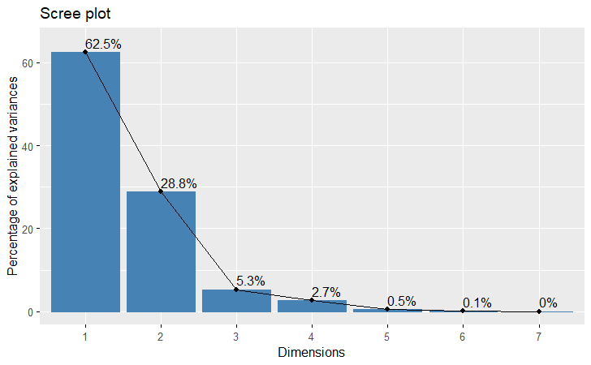

```r
fviz_screeplot(res.ca, addlabels = TRUE, ylim = c(0, 65),ggtheme = theme_get())
```

*Which percentage of variability is explained by the first two dimensions?*

From the graph above and from the values seen before, we can easily conclude that the first 2 dimensions explain 91.31574% of the variability of the entire cloud of points, therefore we can conclude that the first two dimensions are enough to describe the whole contingency table, since they capture a very large percentage of the deviation from independence of our original dataset.

Therefore, an analysis of the plane consisting of the first 2 dimensions would be sufficient to extract conclusions from the performed CA.

### Plots

Let’s build some meaningful plots, since the full CA plot contains lots of overlapping points

The function fviz_ca_biplot() of the package “factoextra” or the function plot.CA() of “FactoMineR of can be used to draw the biplot of rows and columns variables, i.e. to provide a simultaneous representation of rows and columns.

```r
?plot.CA
```

```r
?fviz_ca_biplot # provides ggplot-based elegant visualizations of CA outputs
```

To better render the graph, we limit the number of displayed labels by changing the number of overlaps:

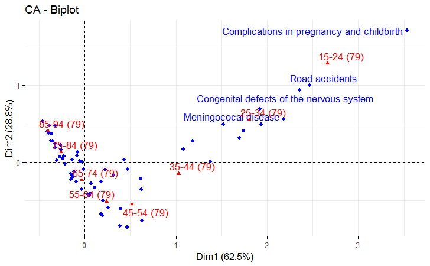

```r
options(ggrepel.max.overlaps =5) # max number of allowed overlaps
fviz_ca_biplot(res.ca, repel = TRUE) # repel avoids text overlapping
```

```r
#plot.CA(res.ca, autoLab="yes", shadowtext="True", graph.type = "ggplot", cex=0.7)
```

The graph above represents all the row and column points. As we can see, due to the presence of a lot of row points and due to overlapping labels, the graph is pretty difficult to be read.

Rows are represented as blue points and cols as red triangles. The distance between any row points or column points gives a measure of their similarity (or dissimilarity). Row points with similar profile are closed on the factor map. The same holds true for column points.

#### Interpretation of the 1st factorial plane

In order to get a useful interpretation of the 1st factorial plane we decide to show only the 10 row points contributing more to the first 2 dimensions, while we add some transparency to the other points.

In order obtain the desired graph it is enough to use the plot.CA function as shown in the code snippet below, where we also add the parameter “cex” to reduce the size of the labels

```r
?plot.CA
```

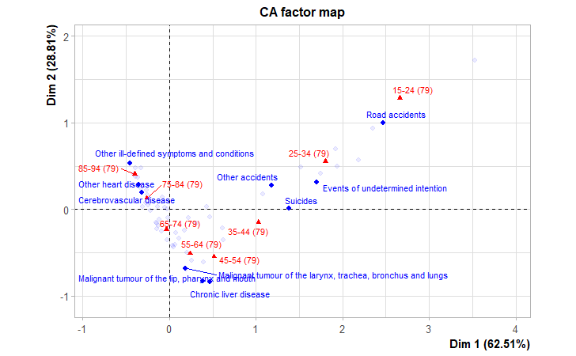

```r
options(ggrepel.max.overlaps = Inf) # max number of allowed overlaps
plot.CA(res.ca, selectRow ="contrib 10", cex=0.65, unselect = 0.92, graph.type = "ggplot", autolab="yes")
```

Let’s now to the following questions:

- *Interpret the first factorial plane (dimensions 1 and 2)*
- *Study the similarities between age groups according to causes of death*
- *Study the similarities between causes of death according to age groups*
- *Which are the main associations between age groups and causes of death?*

The first factorial plane shows that most of the deviation from independence (i.e. inertia of the cloud of points) comes from the separation of the young age ranges, i.e. 15-24, 25-34, 35-44 and the rest.

This plane is able to cluster together causes of death that are more specific to certain age ranges and it also create groups of “similar” age ranges on the basis of the causes of death that they share.

- In particular, the 1st dimension of the plot separates young people (on the right side) from old people (on the left of the origin): it puts in ascending order the ages from the right to the left of the axes. We can see that it also creates a kind of separation between 2 kinds of diseases: on the right there are causes of death not related to illness conditions, while on the left there are illness realated casues of death.
- The 2nd dimension separates the age-range 15-24 (on the top) from the rest of the ranges: in particular it shows an opposition of that range with the range 45-54 and 55-64, that are the middle age ranges. This 2nd dimension also puts in opposition tumour related diseases and “Chronic liver disease” with “Road accidents” (on the top of the 2nd dimension) and other types of diseases, such as heart diseases, “Cerebrovascular disease”, “Other ill-defined symptoms and conditions”, “Other accidents,”Events of undetermined intention” and “Suicides”.
- The position of each cause of death in the first factorial plane shows the ranges of age it affects more. For instance, we can immediately see that causes of death in the first quadrant of the plot are mostly related to young age ranges: for instance “Road accidents” affects more people in the range 15-24 and then 25-34, as expected, since young people are typically more reckless when driving. “Events of undetermined intention”, “Other accidents” and “Suicides” are close to the ranges 25-34 and 35-44. While “Other ill-defined symptoms and conditions”, “Other heart disease”, “Cerebrovascular disease” affects more the older people in the ranges 85-94 and 75-84: again this is an expected behavior. In the lower part of the graph we have all the diseases related to the the middle age ranges, i.e. 35-44, 45-54, 55,64 and also 65-75: the typical diseases for this categories are various types of tumours and “Chronic liver disease”.
- While the position of each range age shows the similarities between the various age ranges, depending on the causes of death: for instance, we can say that the ranges 85-94 and 75-84 are very closed to each other since they share many causes of death; we can say the same for the ranges 55-64, 35-44, 45-54 and evden 65-74 which represent the middle ages; the same reasoning can be also done for the ranges 25-34 and 15-24.

*Overall, what we can say is that the 1st factorial plane is very able to cluster the age-ranges based on the types of disease most frequent for each range and, similarly, it is able to group together causes of deaths that regards specific ages and, finally, it is able to create meaningful associations between age groups and the diseases that typically affect them.*

#### Row analysis

Let’s now briefly analyze separately the row points, i.e. the causes of death.

```r
#head(res.ca$row)
# Output to long to visualize
```

##### Coordinates of row points

Let’s show the coordinates of the row points, i.e. the causes of death, into the newly created dimensions

```r
head(res.ca$row$coord) # coordinates of the first 6 row points
```

```
                                                  Dim 1       Dim 2       Dim 3        Dim 4       Dim 5
Accidental poisoning                         1.52256437  0.49153664  0.08823836  0.148192840  0.02486185
Addiction to prescription medication         1.74271937  0.41144969 -0.14492894 -0.264773294 -0.07873115
Alcohol abuse and alcohol-related psychosis  0.62939789 -0.75946208  0.41762778  0.005976907 -0.16408686
Asthma                                      -0.01584279 -0.09330044 -0.11488909  0.076485869 -0.01701201
Blood and hematopoietic disorders           -0.08711316  0.08335614 -0.03067484  0.043974339 -0.01981214
Cerebrovascular disease                     -0.32208729  0.19292457 -0.02721667  0.028266389 -0.04304305
```

Let’s see how this row points are displayed into the first factorial plane, by showing only the 15 most contributing points to the 1st factorial plane:

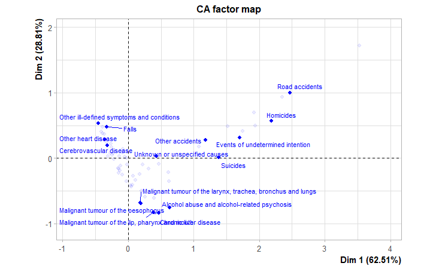

```r
# visualize only row points
options(ggrepel.max.overlaps = Inf) # max number of allowed overlaps
plot.CA(res.ca, selectRow ="contrib 15", cex=0.65, unselect = 0.92, invisible = "col", graph.type = "ggplot", autolab="yes") # show only most contributing points
```

The above plot shows the relationships between row points: rows with a similar profile are grouped together, while negatively correlated rows are positioned on opposite sides of the plot origin (opposed quadrants). The distance between row points and the origin measures the quality of the row points on the factor map. Row points that are away from the origin are well represented on the factor map.

This plot shows again 3 main clusters of causes of death: on the 1st quadrant we have a group of causes of death regarding younger people (as we will see on the graph of column data points), on the bottom we have the diseases regarding middle age people and on the 2nd quadrant we have another group of diseases regarding the older people.

##### Quality of representation of rows

The result of the analysis shows that the contingency table has been successfully represented in two dimensional space using correspondence analysis, indeed the first two dimensions are sufficient to retain more than 90% of the total inertia (variation) contained in the data.

However, not all the points are equally well displayed in the two dimensions.

The quality of representation of the rows on the new dimensions is described by the squared cosine (cos2) or the squared correlations.

The cos2 measures the degree of association between rows/columns and a particular axis. The cos2 of row points can be extracted as follow:

```r
head(res.ca$row$cos2,3) # quality of representation of first 3 row points
```

```
                                                Dim 1      Dim 2       Dim 3        Dim 4        Dim 5
Accidental poisoning                        0.8941117 0.09318634 0.003003000 0.0084702241 0.0002384006
Addiction to prescription medication        0.8808930 0.04910229 0.006092261 0.0203337096 0.0017978831
Alcohol abuse and alcohol-related psychosis 0.3365087 0.48995689 0.148157772 0.0000303458 0.0228714291
```

The values of the cos2 are comprised between 0 and 1. The sum of the cos2 for rows over all the CA dimensions is equal to one.

The quality of representation of a row or column in n dimensions is simply the sum of the squared cosine of that row or column over the n considered dimensions.

If a row item is well represented by two dimensions, the sum of the cos2 is closed to one.

By using the fviz_ca_row() function of “factoextra” we can color row points by their cos2 values.

As shown below, by using gradient.cols = c(“white”, “blue”, “red”) we have that:

- rows with low cos2 values will be colored in “white”
- rows with mid cos2 values will be colored in “blue”
- rows with high cos2 values will be colored in “red”

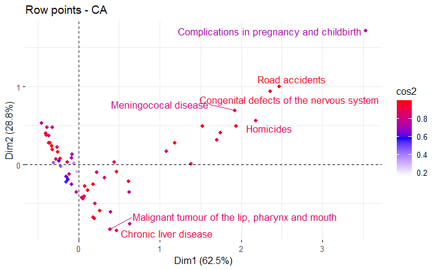

```r
# Color row points by cos2 value
options(ggrepel.max.overlaps = 7) # max number of allowed overlaps
fviz_ca_row(res.ca, col.row = "cos2",
             gradient.cols = c("white", "blue", "red"),
             repel = TRUE)
```

We could also change the transparency of the row points according to their cos2 values using the option alpha.row = “cos2”:

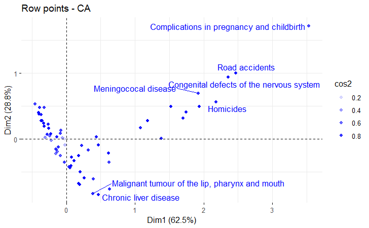

```r
# Change the transparency by cos2 values
options(ggrepel.max.overlaps = 7) # max number of allowed overlaps
fviz_ca_row(res.ca, repel=TRUE, alpha.row="cos2")
```

It’s also possible to create a bar plot of the rows cos2 using the function fviz_cos2() of the faxtoextra package:

```r
?fviz_cos2
```

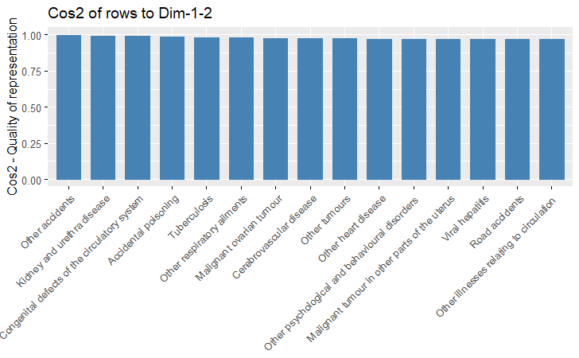

```r
# Cos2 of rows on Dim.1 and Dim.2
fviz_cos2(res.ca, choice = "row", axes = 1:2, repel=TRUE, top=15, ggtheme=theme_get()) # show only top 15
```

The above plot shows the 15 row points better represented by the first 2 dimensions, i.e. whose intertia is better captured by the first factorial plane.

##### Contributions of rows to the dimensions

Let’s now see how much each row point contributes to the inertia captured by each new dimension

```r
head(res.ca$row$contrib)
```

```
                                                   Dim 1      Dim 2       Dim 3       Dim 4       Dim 5
Accidental poisoning                        0.7768205988 0.17566872 0.030767718 0.169606708  0.02634208
Addiction to prescription medication        0.0669012980 0.00809145 0.005456333 0.035591571  0.01736547
Alcohol abuse and alcohol-related psychosis 0.8908760116 2.81444094 4.625476176 0.001851564  7.70066202
Asthma                                      0.0002479651 0.01865985 0.153778634 0.133201462  0.03636240
Blood and hematopoietic disorders           0.0109113619 0.02167703 0.015954642 0.064080990  0.07177744
Cerebrovascular disease                     4.5014552838 3.50424211 0.379041337 0.799034628 10.22411022
```

The row variables with the larger value, contribute the most to the definition of the dimensions.

The function fviz_contrib() of factoextra package can be used to draw a bar plot of row contributions.

The bar plot of the total contribution to dimension 1 and 2 can be obtained as follow:

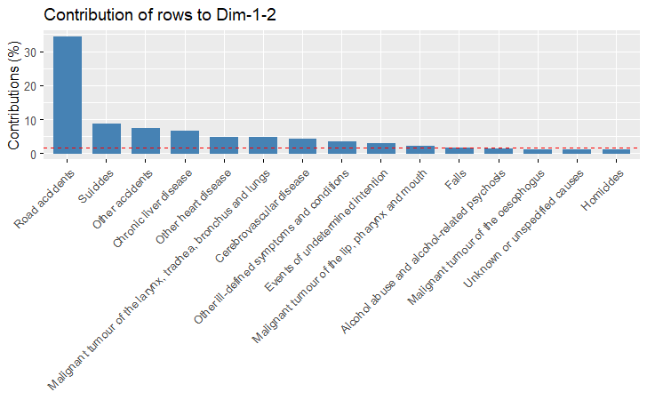

```r
fviz_contrib(res.ca, choice = "row", axes = 1:2, top = 15, ggtheme=theme_get()) # just show the top 15 contributing rows
```

The rows “Road accidents”, “Suicides”, “Other accidents” are three the most important rows in the definition of the first two dimensions.

In order to see the rows, i.e. the causes of death, that contribute most to the first dimension:

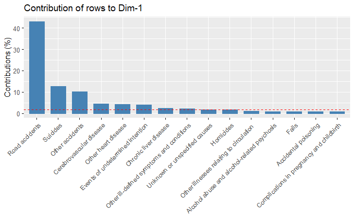

```r
fviz_contrib(res.ca, choice = "row", axes = 1, top = 15, ggtheme=theme_get()) # just show the top 15 contributing rows
```

*What are the three causes of death most influencing the formation of the first principal component?*

The rows “Road accidents”, “Suicides”, “Other accidents” are the three most important cause of death in the definition of the first dimension.

As seen for the cos2, the most contributing row points can be highlighted on the plot of row points as follows:

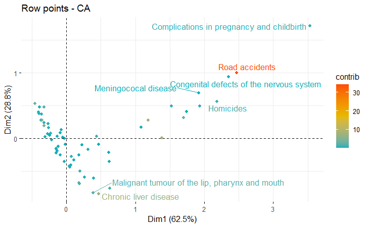

```r
fviz_ca_row(res.ca, col.row = "contrib",
             gradient.cols = c("#00AFBB", "#E7B800", "#FC4E07"),
             repel = TRUE)
```

Note that, it’s also possible to control the transparency of row points according to their contribution values using the option alpha.row = “contrib”, as shown below:

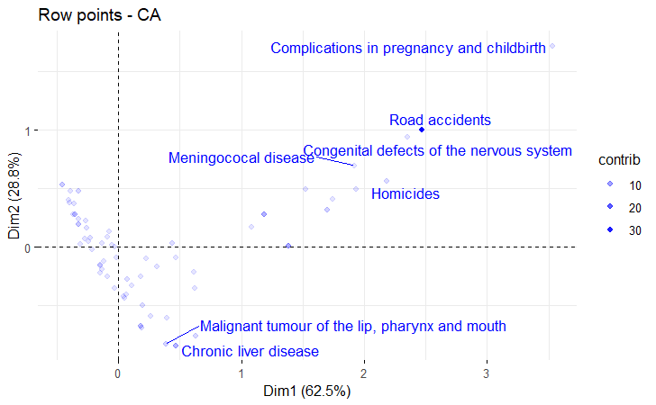

```r
# Change the transparency by contrib values
fviz_ca_row(res.ca, alpha.row="contrib",
             repel = TRUE)
```

#### Column analysis

We can repeat the same analysis done for the rows also for the columns

```r
#head(res.ca$col)
# Output to long to visualize
```

##### Coordinates of column points

```r
res.ca$col$coord  # coordinates of the column points (i.e. age ranges) in the new dimensions
```

```
                 Dim 1      Dim 2       Dim 3       Dim 4       Dim 5
15-24 (79)  2.66139352  1.2881248 -0.46058627 -0.37378820 -0.01854162
25-34 (79)  1.80343468  0.5557732  0.27898687  0.53672333  0.12151596
35-44 (79)  1.02922118 -0.1484518  0.33459861  0.16272816 -0.10052528
45-54 (79)  0.51791921 -0.5459508  0.21579326 -0.11820016 -0.06760452
55-64 (79)  0.23995827 -0.5090604  0.01974193 -0.08156573  0.05138066
65-74 (79) -0.03321675 -0.2294961 -0.13861248  0.02978175  0.03476755
75-84 (79) -0.25919472  0.1311802 -0.07393034  0.05126472 -0.04181828
85-94 (79) -0.40085591  0.4101576  0.18804134 -0.08370686  0.03475306
```

Let’s visualize how column points are positioned in the first factorial plane

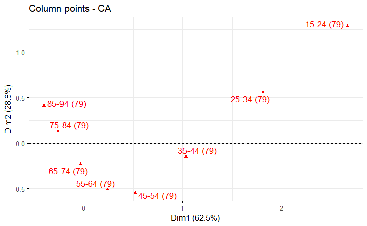

```r
# visualize only col points
fviz_ca_col(res.ca, repel = TRUE)
```

The plot above shows the relationships between column points: columns with a similar profile are grouped together, i.e. in our case age-ranges that share many causes of death are clustered together.

As said before, the CA allows to create groups of age ranges based on the causes of death they share.

##### Quality of representation of columns

As seen for the row points, the cos2 of col points can be extracted as follow:

```r
res.ca$col$cos2
```

```
                Dim 1      Dim 2       Dim 3      Dim 4        Dim 5
15-24 (79) 0.77882119 0.18244648 0.023326069 0.01536281 3.780199e-05
25-34 (79) 0.82407360 0.07826370 0.019721171 0.07299046 3.741380e-03
35-44 (79) 0.85173634 0.01771979 0.090019381 0.02129184 8.125280e-03
45-54 (79) 0.42350365 0.47058715 0.073520573 0.02205816 7.215801e-03
55-64 (79) 0.17598569 0.79203542 0.001191201 0.02033393 8.068732e-03
65-74 (79) 0.01462187 0.69797369 0.254620435 0.01175409 1.601905e-02
75-84 (79) 0.71197029 0.18236707 0.057923530 0.02785138 1.853283e-02
85-94 (79) 0.43132724 0.45157707 0.094915462 0.01880843 3.242026e-03
```

Let’s color column points depending on their cos2 value for the first 2 dimensions:

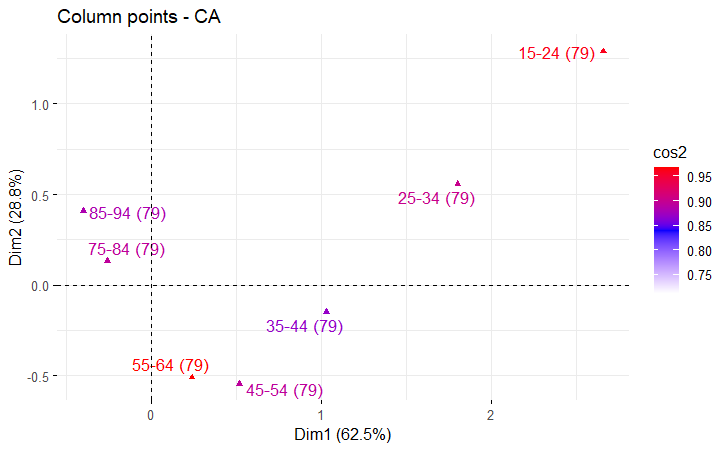

```r
# Color by cos2 values: quality on the factor map
fviz_ca_col(res.ca, col.col = "cos2",
             gradient.cols = c("white", "blue", "red"),
             repel = TRUE)
```

As done for rows , we can change the transparency of the col points according to their cos2 values using the option alpha.col = “cos2”:

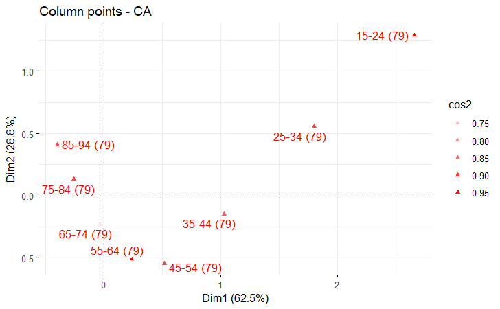

```r
# Change the transparency by cos2 values
fviz_ca_col(res.ca, repel=TRUE, alpha.col ="cos2")
```

It’s also possible to create a bar plot of cols cos2:

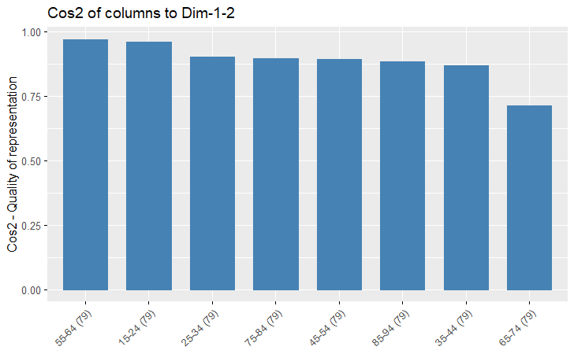

```r
# Cos2 of columns on Dim.1 and Dim.2
fviz_cos2(res.ca, choice = "col", axes = 1:2, ggtheme=theme_get())
```

*What are the age intervals best represented in the first factorial plane?*

The above bar plot shows, in descending order, the quality of representation of columns (i.e. age intervals) on the first 2 dimensions. We can easily see that the best represented age ranges are, in order: 55-64 followed by 15-24, 25-34, 75-84, 45-54, 85-94, 35-44, 65-74

```r
?fviz_cos2
```

##### Contributions of cols to the dimensions

To see the contribution of each column (age range) to each new dimension:

```r
head(res.ca$col$contrib)
```

```
                 Dim 1      Dim 2     Dim 3     Dim 4      Dim 5
15-24 (79) 42.26421605 21.4824491 14.927518 19.214318  0.2608936
25-34 (79) 20.69429118  4.2644027  5.840207 42.244468 11.9489595
35-44 (79)  9.93834264  0.4486219 12.386705  5.725865 12.0576004
45-54 (79)  6.78444521 16.3572575 13.889194  8.144147 14.7012916
55-64 (79)  2.09517974 20.4598194  0.167240  5.579362 12.2169556
65-74 (79)  0.09136286  9.4627896 18.761654  1.692680 12.7296773
```

As done for rows, we can use a bar plot of columns contributions to show the most contributing columns.

The total contribution of each columns to the first 2 dimensions can be obtained as follow:

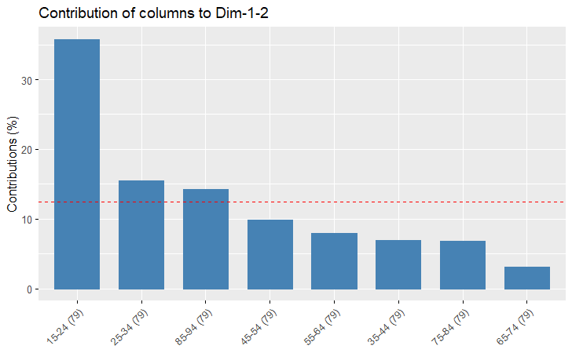

```r
fviz_contrib(res.ca, choice = "col", axes = 1:2, ggtheme=theme_get())
```

The age ragnes 15-24, 25-34, 85-94 are the 3 most contributing to the variance of the first 2 dimensions.

We can highlight on the biplot the contribution of each column :

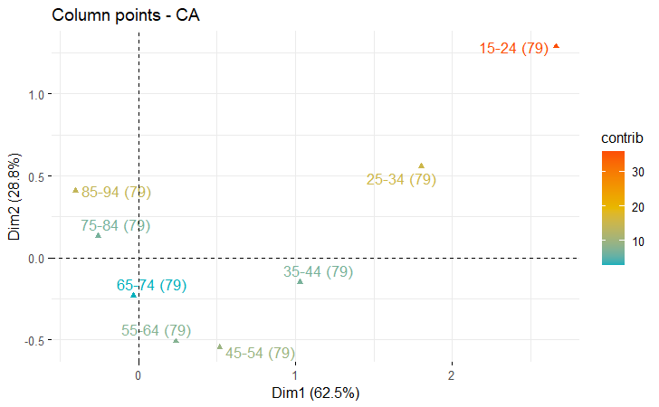

```r
fviz_ca_col(res.ca, col.col =  "contrib",
             gradient.cols = c("#00AFBB", "#E7B800", "#FC4E07"),
             repel = TRUE)
```

We can also control the transparency of column points according to their contributions:

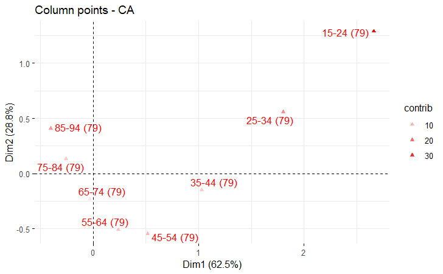

```r
# Change the transparency by contrib values
fviz_ca_col(res.ca, alpha.col="contrib",
             repel = TRUE)
```